# Visualizing concept lattices: from R to LaTeX

```r
library(fcaR)
```

Visualization is a fundamental component of Formal Concept Analysis (FCA). The lattice structure reveals hierarchical relationships and implications between data that are difficult to detect in a flat table.

`fcaR` provides a flexible plotting system based on `ggplot2` and `ggraph`, as well as a powerful tool for exporting to **LaTeX (TikZ)** to generate high-quality figures ready for academic publication.

In this guide, we will use the classic `planets` dataset included in the package.

```r
# Load the context and find concepts
fc <- FormalContext$new(planets)
fc$find_concepts()
```

## 1. Standard visualization

The simplest way to visualize the lattice is by using the `plot()` method on the concepts object.

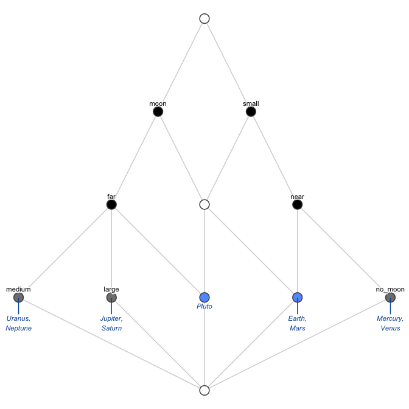

```r
fc$concepts$plot()
```

By default, `fcaR` applies a heuristic to decide the best visualization mode based on the size of the lattice (usually reduced labeling and hierarchical layout).

### Layout algorithms

`fcaR` implements two main algorithms to position the nodes (concepts) in space:

#### 1. Sugiyama layout (layered)

This is the default value (`method = "sugiyama"`). It arranges concepts in horizontal layers based on their generality (grade) and minimizes edge crossings. It is ideal for classic **Hasse diagrams**.

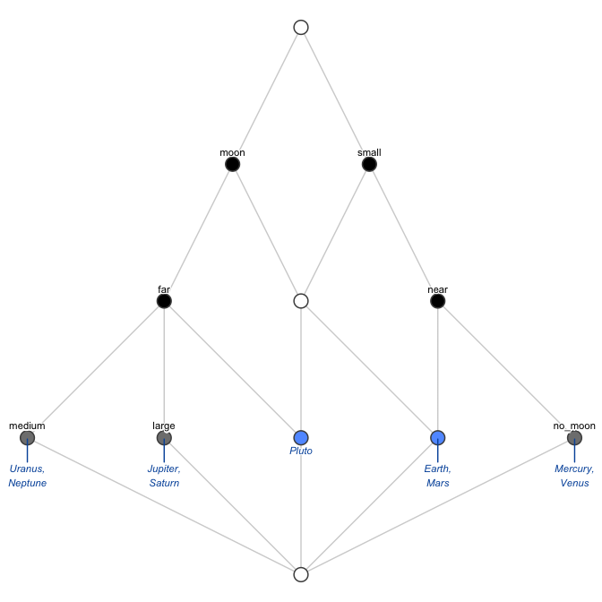

```r
fc$concepts$plot(method = "sugiyama")
```

#### 2. Force-directed layout (organic)

The force-directed layout (`method = "force"`) simulates a physical system where nodes repel each other and edges act like springs. It is useful for very large, dense lattices or when the strict hierarchy makes the graph too wide.

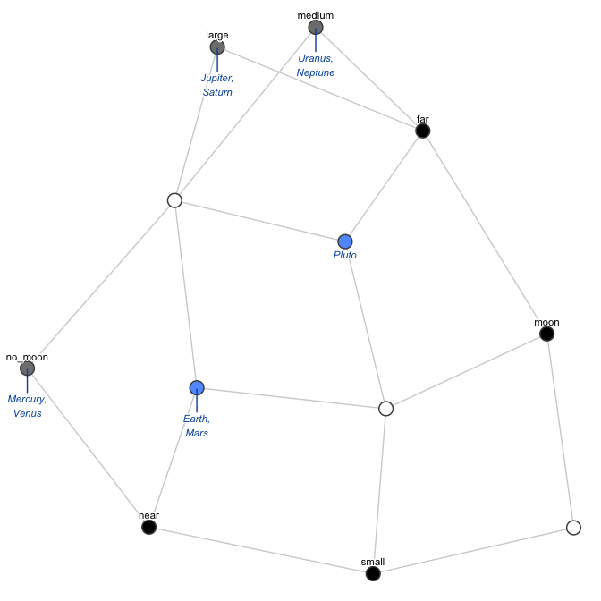

```r
fc$concepts$plot(method = "force")
```

## 2. Labeling modes

Information density is a challenge in lattice visualization. `fcaR` offers several modes (`mode`) to control what information is shown on the nodes.

### Reduced labeling

This is the standard in FCA literature (`mode = "reduced"`). To avoid redundancy:

- An **attribute** is shown only on the highest concept (supremum) that contains it.
- An **object** is shown only on the lowest concept (infimum) that contains it.

This makes the graph easier to read: a concept possesses all attributes labeled on it and its ancestors (above), and possesses all objects labeled on it and its descendants (below).

The color code helps identify the nature of the node:

- **Black:** Introduces attributes (Attribute Concept).
- **Blue:** Introduces objects (Object Concept).
- **Gray:** Introduces both (Clarified Concept).
- **White:** Introduces nothing new (it is just an intersection of other concepts).

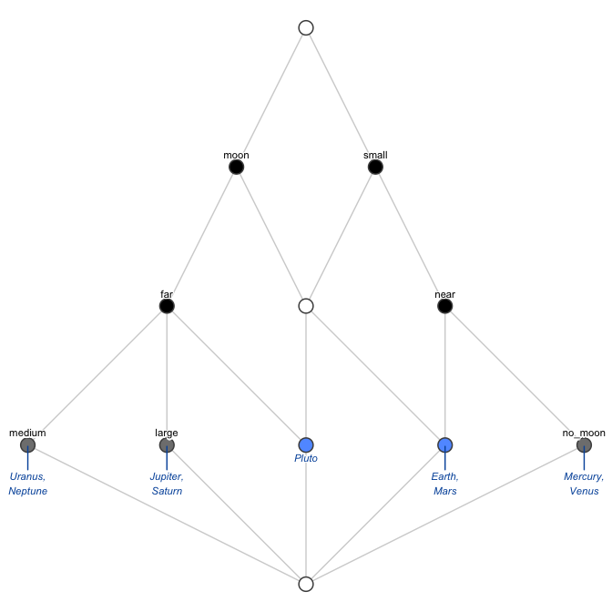

```r
fc$concepts$plot(mode = "reduced")
```

### Full labeling

For educational purposes or very small lattices, it can be useful to see the full extent (objects) and intent (attributes) in each node.

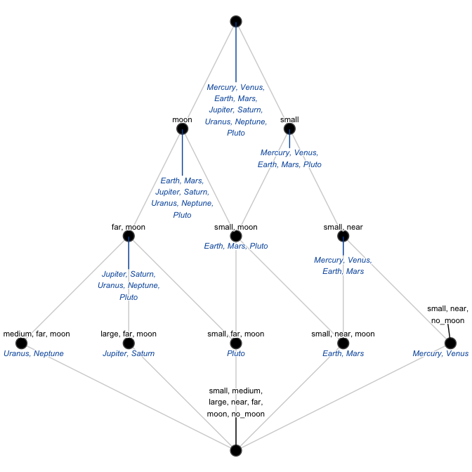

```r
fc$concepts$plot(mode = "full")
```

### Empty (structure only)

For large lattices (> 50 concepts), text labels can overlap and obscure the structure. The `"empty"` mode draws only the nodes and edges.

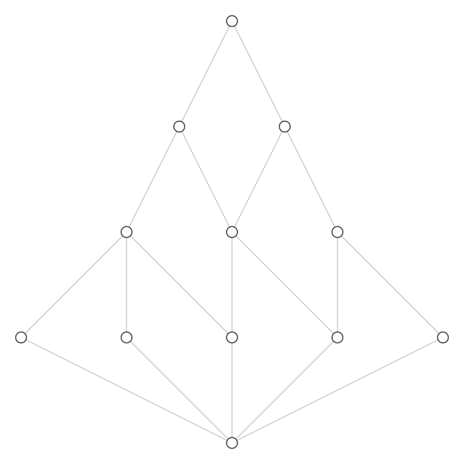

```r
fc$concepts$plot(mode = "empty")
```

## 3. Exporting to LaTeX (TikZ)

For *papers* and scientific presentations, raster graphics (PNG, JPEG) often lose quality. `fcaR` allows exporting the calculated layout directly to **TikZ** code (vector graphics), which can be pasted into a LaTeX document.

To generate the code, use the argument `to_latex = TRUE`. This **does not** draw the plot in R, but returns a special object with the source code.

```r
# Generate TikZ code
tikz_code <- fc$concepts$plot(to_latex = TRUE)

# The object prints cleanly to the console
tikz_code
```

```
#> %%% Concept Lattice generated by fcaR %%%
#> \definecolor{col619CFF}{HTML}{619CFF}
#> \begin{tikzpicture}[
#>   node_style/.style={circle, draw=gray!80, line width=0.5pt, inner sep=2.5pt},
#>   edge_style/.style={draw=gray!60, line width=0.8pt}
#> ]
#>   \draw[edge_style] (6.00, 7.20) -- (4.80, 9.60);
#>   \draw[edge_style] (3.60, 7.20) -- (4.80, 9.60);
#>   \draw[edge_style] (4.80, 0.00) -- (0.00, 2.40);
#>   \draw[edge_style] (4.80, 0.00) -- (2.40, 2.40);
#>   \draw[edge_style] (4.80, 0.00) -- (9.60, 2.40);
#>   \draw[edge_style] (9.60, 2.40) -- (7.20, 4.80);
#>   \draw[edge_style] (7.20, 2.40) -- (7.20, 4.80);
#>   \draw[edge_style] (4.80, 0.00) -- (7.20, 2.40);
#>   \draw[edge_style] (7.20, 4.80) -- (6.00, 7.20);
#>   \draw[edge_style] (4.80, 4.80) -- (6.00, 7.20);
#>   \draw[edge_style] (4.80, 0.00) -- (4.80, 2.40);
#>   \draw[edge_style] (7.20, 2.40) -- (4.80, 4.80);
#>   \draw[edge_style] (4.80, 2.40) -- (4.80, 4.80);
#>   \draw[edge_style] (0.00, 2.40) -- (2.40, 4.80);
#>   \draw[edge_style] (2.40, 2.40) -- (2.40, 4.80);
#>   \draw[edge_style] (4.80, 2.40) -- (2.40, 4.80);
#>   \draw[edge_style] (4.80, 4.80) -- (3.60, 7.20);
#>   \draw[edge_style] (2.40, 4.80) -- (3.60, 7.20);
#>   \node[node_style, fill=white] at (4.80, 0.00) {};
#>   \node[node_style, fill=white] at (4.80, 9.60) {};
#>   \node[node_style, fill=gray!50, label={[align=center, font=\sffamily\tiny, yshift=2pt]90:{medium}}, label={[align=center, font=\itshape\tiny, text=blue!80!black, yshift=-2pt]270:{Uranus,\\Neptune}}] at (0.00, 2.40) {};
#>   \node[node_style, fill=gray!50, label={[align=center, font=\sffamily\tiny, yshift=2pt]90:{large}}, label={[align=center, font=\itshape\tiny, text=blue!80!black, yshift=-2pt]270:{Jupiter,\\Saturn}}] at (2.40, 2.40) {};
#>   \node[node_style, fill=gray!50, label={[align=center, font=\sffamily\tiny, yshift=2pt]90:{no\_moon}}, label={[align=center, font=\itshape\tiny, text=blue!80!black, yshift=-2pt]270:{Mercury,\\Venus}}] at (9.60, 2.40) {};
#>   \node[node_style, fill=black, label={[align=center, font=\sffamily\tiny, yshift=2pt]90:{near}}] at (7.20, 4.80) {};
#>   \node[node_style, fill=col619CFF, label={[align=center, font=\itshape\tiny, text=blue!80!black, yshift=-2pt]270:{Earth,\\Mars}}] at (7.20, 2.40) {};
#>   \node[node_style, fill=black, label={[align=center, font=\sffamily\tiny, yshift=2pt]90:{small}}] at (6.00, 7.20) {};
#>   \node[node_style, fill=col619CFF, label={[align=center, font=\itshape\tiny, text=blue!80!black, yshift=-2pt]270:{Pluto}}] at (4.80, 2.40) {};
#>   \node[node_style, fill=white] at (4.80, 4.80) {};
#>   \node[node_style, fill=black, label={[align=center, font=\sffamily\tiny, yshift=2pt]90:{far}}] at (2.40, 4.80) {};
#>   \node[node_style, fill=black, label={[align=center, font=\sffamily\tiny, yshift=2pt]90:{moon}}] at (3.60, 7.20) {};
#> \end{tikzpicture}
```

### Saving to a file

You can save the code directly to a `.tex` file using the `save_tikz()` function and the R pipe operator:

```r
# Save to a local file
fc$concepts$plot(to_latex = TRUE) |>
  save_tikz("lattice_diagram.tex")
```

### How to use it in LaTeX

To compile the generated code, ensure you include the following packages in your LaTeX document preamble:

```latex
\documentclass{article}
\usepackage{tikz}
\usetikzlibrary{shapes, arrows, positioning}

\begin{document}

\begin{figure}[h]
    \centering
    % You can use \input{lattice_diagram.tex} here
    % or paste the generated code directly:

    \begin{tikzpicture}... \end{tikzpicture}

    \caption{Concept lattice generated with fcaR.}
\end{figure}

\end{document}
```